# **Chapter 3: Logistic regression**

```r
date()
```

```
## [1] "Tue Nov 29 00:24:07 2022"
```

## **Analysis exercises**

### **Task 2.**

> The CSV file for this week’s assignment contains modified data from a study done by Prof. Paulo Cortez and Alice Silva, and which was published in 2008 ([source](http://www3.dsi.uminho.pt/pcortez/student.pdf)). The table has measurements (obtained via school reports and questionnaires) of variables related to the students’ performances in mathematics and Portuguese from secondary education in two Portuguese schools (Gabriel Pereira and Mousinho da Silveira). The following attributes are found in the dataset:

```r
library(tidyverse)

student_alc <- read_csv(file = "https://raw.githubusercontent.com/KimmoVehkalahti/Helsinki-Open-Data-Science/master/datasets/alc.csv", col_names = TRUE)
colnames(student_alc)
```

```
##  [1] "school"     "sex"        "age"        "address"    "famsize"
##  [6] "Pstatus"    "Medu"       "Fedu"       "Mjob"       "Fjob"
## [11] "reason"     "guardian"   "traveltime" "studytime"  "schoolsup"
## [16] "famsup"     "activities" "nursery"    "higher"     "internet"
## [21] "romantic"   "famrel"     "freetime"   "goout"      "Dalc"
## [26] "Walc"       "health"     "failures"   "paid"       "absences"
## [31] "G1"         "G2"         "G3"         "alc_use"    "high_use"
```

> The “high_use” is an added variable, and can be either TRUE or FALSE depending on whether “alc_use” is higher than two or not.

### **Task 3.**

> Due to the file containing so many interesting variables to choose from, I decided to let R — and fate — choose the ones I will be using for the rest of the exercises. These were:

```r
set.seed(2135) # Seed number for reproducibility, when using random sampling.

interesting_variables <- sample(colnames(student_alc), size = 4, replace = FALSE)
interesting_variables
```

```
## [1] "freetime"   "sex"        "traveltime" "Pstatus"
```

> The **Free time** after school could have connections to high alcohol usage as the more time you have after school, especially if you’re a student between 15 to 22 years old, the more time you have for a drink (or two). **Sex** might have also connections because men typically drink more that women. **Travel time**, which is specified to be from home to school, is a bit harder to imagine to be related to high alcohol consumption. Maybe Portuguese students drink during long trips to school? Who knows. ¯\_(ツ)_/¯ Lastly, the **parent’s cohabitation status** (together or apart) might have negative correlation due to children in two-parent households having both parents to look after them, thus having less opportunities or reasons to drink.

### **Task 4.**

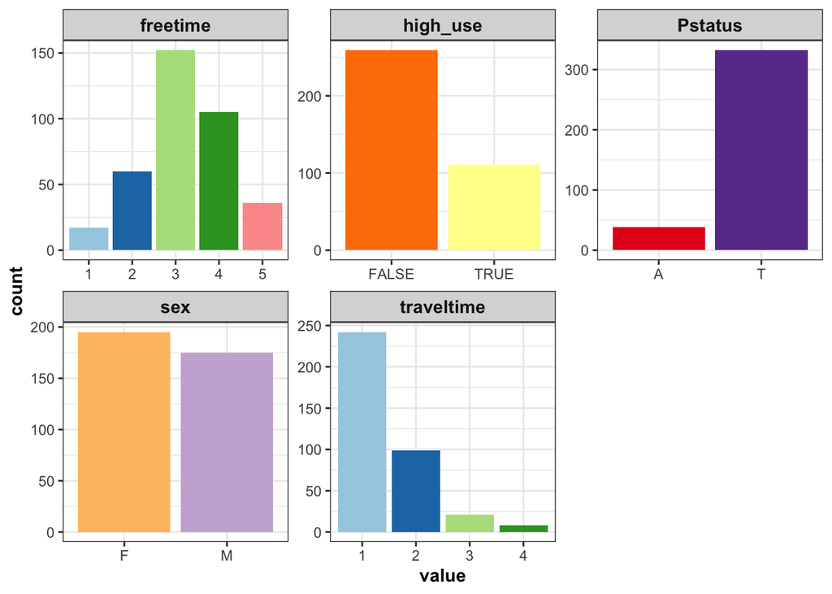

```r
library(RColorBrewer)
library(patchwork)
library(gridExtra)

interesting_variables <- append(interesting_variables, "high_use")

student_alc %>%
  select(all_of(interesting_variables)) %>% gather() %>%
ggplot(aes(value, fill = value)) +
  geom_bar() +
  scale_fill_brewer(palette = "Paired", guide = "none") +
  theme_bw() +
  theme(strip.text = element_text(size = 11, face = "bold"),
        axis.title = element_text(size = 11, face = "bold")) +
  facet_wrap("key", scales = "free")
```

> Looking at the bar plots for the interesting variables, I notice that observations for free time are almost normally distributed. Most of the student don’t have high alcohol usage. Interestingly, there is quite a skew with the parent’s cohabitation status with most being together. The sex distribution is almost equal, and most students have a short travel time to school.

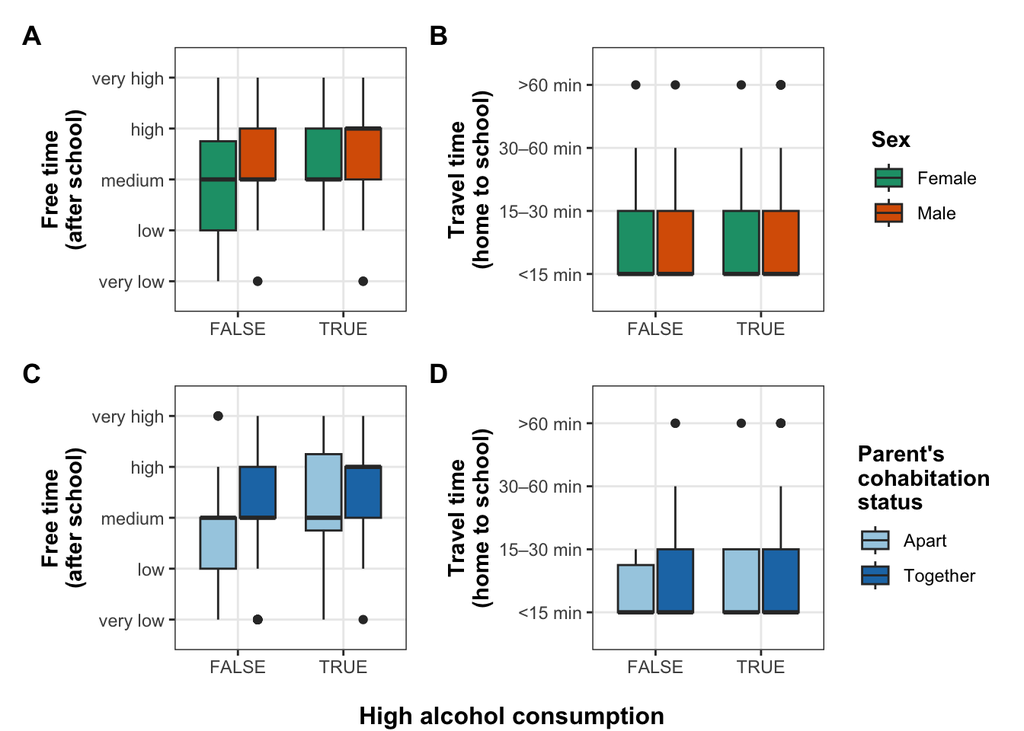

```r
library(ggpubr)

new_student_alc <- student_alc %>%
  select(all_of(interesting_variables))

plot_a <-
  ggplot(new_student_alc, aes(x = high_use, y = freetime, fill = sex)) +
  geom_boxplot() +
  scale_fill_brewer(
    palette = "Dark2",
    name = "Sex",
    labels = c("Female", "Male")
  ) +
  scale_y_discrete(limits = c("very low", "low", "medium", "high", "very high")) +
  ylab("Free time\n(after school)") +
  theme_bw() +
  theme(
    axis.title.x = element_blank(),
    axis.title = element_text(face = "bold"),
    legend.title = element_text(face = "bold")
  )

plot_b <-
  ggplot(new_student_alc, aes(x = high_use, y = traveltime, fill = sex)) +
  geom_boxplot() +
  scale_fill_brewer(
    palette = "Dark2",
    name = "Sex",
    labels = c("Female", "Male")
  ) +
  scale_y_discrete(limits = c("<15 min", "15–30 min", "30–60 min", ">60 min")) +
  ylab("Travel time\n(home to school)") +
  theme_bw() +
  theme(
    axis.title.x = element_blank(),
    axis.title = element_text(face = "bold"),
    legend.title = element_text(face = "bold")
  )

plot_c <-
  ggplot(new_student_alc, aes(x = high_use, y = freetime, fill = Pstatus)) +
  geom_boxplot() +
  scale_fill_brewer(
    palette = "Paired",
    name = "Parent's\ncohabitation\nstatus",
    labels = c("Apart", "Together")
  ) +
  scale_y_discrete(limits = c("very low", "low", "medium", "high", "very high")) +
  ylab("Free time\n(after school)") +
  theme_bw() +
  theme(
    axis.title.x = element_blank(),
    axis.title = element_text(face = "bold"),
    legend.title = element_text(face = "bold")
  )

plot_d <-
  ggplot(new_student_alc, aes(x = high_use, y = traveltime, fill = Pstatus)) +
  geom_boxplot() +
  scale_fill_brewer(
    palette = "Paired",
    name = "Parent's\ncohabitation\nstatus",
    labels = c("Apart", "Together")
  ) +
  scale_y_discrete(limits = c("<15 min", "15–30 min", "30–60 min", ">60 min")) +
  ylab("Travel time\n(home to school)") +
  theme_bw() +
  theme(
    axis.title.x = element_blank(),
    axis.title = element_text(face = "bold"),
    legend.title = element_text(face = "bold")
  )

joined_plot <- (plot_a + plot_b + plot_layout(guides = "collect")) /
  (plot_c + plot_d + plot_layout(guides = "collect")) +
  plot_annotation(tag_levels = "A") &
  theme(plot.tag = element_text(face = "bold"))

grid.arrange(
  patchworkGrob(joined_plot),
  bottom = text_grob("High alcohol consumption", face = "bold")
)
```

### **Task 5.**

```r
model <- glm(high_use ~ freetime + sex + traveltime + Pstatus - 1, data = student_alc, family = "binomial")
summary(model)
```

```
##
## Call:
## glm(formula = high_use ~ freetime + sex + traveltime + Pstatus -
##     1, family = "binomial", data = student_alc)
##
## Deviance Residuals:
##     Min       1Q   Median       3Q      Max
## -1.3632  -0.8695  -0.6220   1.1984   1.9127
##
## Coefficients:
##            Estimate Std. Error z value Pr(>|z|)
## freetime     0.3023     0.1253   2.413   0.0158 *
## sexF        -2.6603     0.5946  -4.474 7.69e-06 ***
## sexM        -1.8937     0.6263  -3.023   0.0025 **
## traveltime   0.4015     0.1617   2.483   0.0130 *
## PstatusT    -0.1924     0.3912  -0.492   0.6228
## ---
## Signif. codes:  0 '***' 0.001 '**' 0.01 '*' 0.05 '.' 0.1 ' ' 1
##
## (Dispersion parameter for binomial family taken to be 1)
##
##     Null deviance: 512.93  on 370  degrees of freedom
## Residual deviance: 424.31  on 365  degrees of freedom
## AIC: 434.31
##
## Number of Fisher Scoring iterations: 4
```

> The summary shows that Pstatus might not statistically significant in my model.

```r
OR <- coef(model) %>% exp
CI <- confint(model) %>% exp
cbind(OR, CI)
```

```
##                    OR      2.5 %    97.5 %
## freetime   1.35291603 1.06175190 1.7370368
## sexF       0.06992947 0.02089100 0.2168783
## sexM       0.15051787 0.04259748 0.5008024
## traveltime 1.49409723 1.08919695 2.0594122
## PstatusT   0.82496011 0.38967324 1.8280994
```

```r
library(finalfit)

factor_student_alc <-
  new_student_alc %>%
  mutate(sex = factor(sex) %>%
           fct_recode("Female" = "F",
                      "Male"   = "M") %>%
           ff_label("Sex")) %>%
  mutate(
    Pstatus = factor(Pstatus) %>%
      fct_recode("Apart" = "A",
                 "Together"   = "T") %>%
      ff_label("Parent's cohabitation status")
  ) %>%
  mutate(
    traveltime = factor(traveltime) %>%
      fct_recode(
        "<15 min" = "1",
        "15–30 min" = "2",
        "30–60 min" = "3",
        ">60 min" = "4"
      ) %>%
      ff_label("Travel time (home to school)")
  ) %>%
  mutate(
    freetime = factor(freetime) %>%
      fct_recode(
        "very low" = "1",
        "low" = "2",
        "medium" = "3",
        "high" = "4",
        "very high"   = "5"
      ) %>%
      ff_label("Free time (after school)")
  ) %>%
  mutate(high_use = ff_label(high_use, "High alcohol consumption"))

factor_student_alc %>%
  summary_factorlist(
    "high_use",
    c("freetime", "sex", "traveltime", "Pstatus"),
    p = TRUE,
    add_dependent_label = TRUE
  )
```

```
##  Dependent: High alcohol consumption                FALSE      TRUE      p
##             Free time (after school)  very low   15 (5.8)   2 (1.8)  0.032
##                                            low  46 (17.8) 14 (12.6)
##                                         medium 112 (43.2) 40 (36.0)
##                                           high  65 (25.1) 40 (36.0)
##                                      very high   21 (8.1) 15 (13.5)
##                                  Sex    Female 154 (59.5) 41 (36.9) <0.001
##                                           Male 105 (40.5) 70 (63.1)
##         Travel time (home to school)   <15 min 174 (67.2) 68 (61.3)  0.003
##                                      15–30 min  73 (28.2) 26 (23.4)
##                                      30–60 min   10 (3.9)  11 (9.9)
##                                        >60 min    2 (0.8)   6 (5.4)
##         Parent's cohabitation status     Apart  26 (10.0) 12 (10.8)  0.970
##                                       Together 233 (90.0) 99 (89.2)
```

> Using summary_factorlist() from the finalfit package reveals the same.

```r
factor_student_alc %>%
  finalfit("high_use",
           c("sex", "Pstatus", "traveltime", "freetime"),
           metrics = TRUE)
```

```
## [[1]]
##  Dependent: High alcohol consumption                FALSE      TRUE
##                                  Sex    Female 154 (79.0) 41 (21.0)
##                                           Male 105 (60.0) 70 (40.0)
##         Parent's cohabitation status     Apart  26 (68.4) 12 (31.6)
##                                       Together 233 (70.2) 99 (29.8)
##         Travel time (home to school)   <15 min 174 (71.9) 68 (28.1)
##                                      15–30 min  73 (73.7) 26 (26.3)
##                                      30–60 min  10 (47.6) 11 (52.4)
##                                        >60 min   2 (25.0)  6 (75.0)
##             Free time (after school)  very low  15 (88.2)  2 (11.8)
##                                            low  46 (76.7) 14 (23.3)
##                                         medium 112 (73.7) 40 (26.3)
##                                           high  65 (61.9) 40 (38.1)
##                                      very high  21 (58.3) 15 (41.7)
##                OR (univariable)             OR (multivariable)
##                               -                              -
##    0.19 (0.10 to 0.28, p<0.001)   0.15 (0.06 to 0.25, p=0.002)
##                               -                              -
##  -0.02 (-0.17 to 0.14, p=0.823) -0.06 (-0.21 to 0.09, p=0.464)
##                               -                              -
##  -0.02 (-0.12 to 0.09, p=0.734) -0.02 (-0.12 to 0.09, p=0.724)
##    0.24 (0.04 to 0.45, p=0.019)   0.25 (0.05 to 0.45, p=0.015)
##    0.47 (0.15 to 0.79, p=0.004)   0.42 (0.10 to 0.73, p=0.010)
##                               -                              -
##   0.12 (-0.13 to 0.36, p=0.355)  0.08 (-0.16 to 0.32, p=0.525)
##   0.15 (-0.08 to 0.37, p=0.212)  0.11 (-0.11 to 0.33, p=0.334)
##    0.26 (0.03 to 0.50, p=0.027)  0.22 (-0.01 to 0.45, p=0.066)
##    0.30 (0.04 to 0.56, p=0.026)  0.21 (-0.06 to 0.47, p=0.124)
##
## [[2]]
##
##  Number in dataframe = 370, Number in model = 370, Missing = 0, Log-likelihood = -218.3, AIC = 458.6, R-squared = 0.093, Adjusted R-squared = 0.07
```

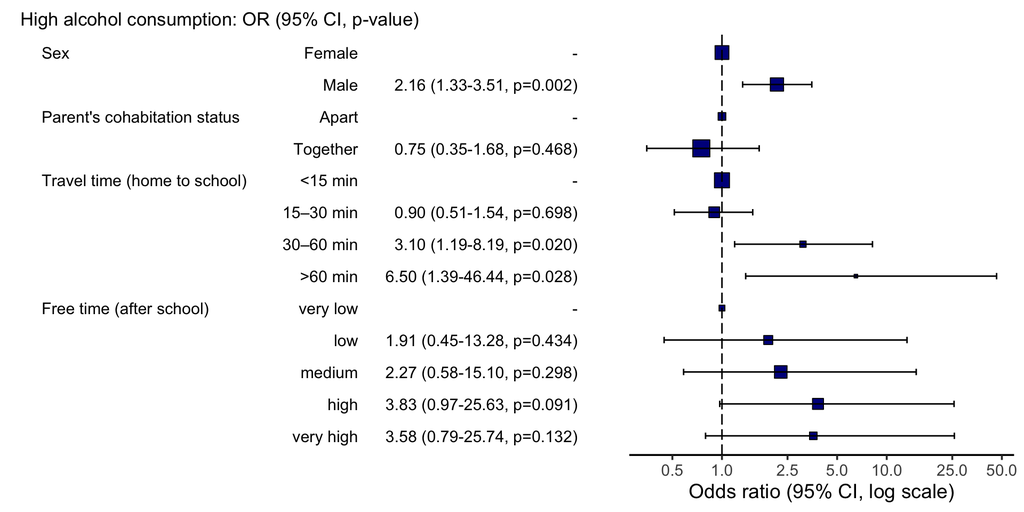

```r
factor_student_alc %>%
  or_plot(
    "high_use",
    c("sex", "Pstatus", "traveltime", "freetime"),
    title_text_size = 13,
    table_text_size = 4,
    column_space = c(-3, 3.2, 7.5),
    breaks = c(0.5, 1, 2.5, 5, 10, 25, 50)
  )
```

### **Task 6.**

> Based on the previous model results, I will exclude Pstatus from further analyses.

```r
model <- glm(high_use ~ sex + freetime + traveltime - 1, data = factor_student_alc, family = "binomial")
probabilities <- predict(model, type = "response")
factor_student_alc <- mutate(factor_student_alc, probability = probabilities) %>%
  mutate(factor_student_alc, prediction = probability > 0.5)
table(high_use = factor_student_alc$high_use, prediction = factor_student_alc$prediction)
```

```
##         prediction
## high_use FALSE TRUE
##    FALSE   252    7
##    TRUE     97   14
```

```r
table(high_use = factor_student_alc$high_use,
      prediction = factor_student_alc$prediction) %>% prop.table() %>% addmargins()
```

```
##         prediction
## high_use      FALSE       TRUE        Sum
##    FALSE 0.68108108 0.01891892 0.70000000
##    TRUE  0.26216216 0.03783784 0.30000000
##    Sum   0.94324324 0.05675676 1.00000000
```

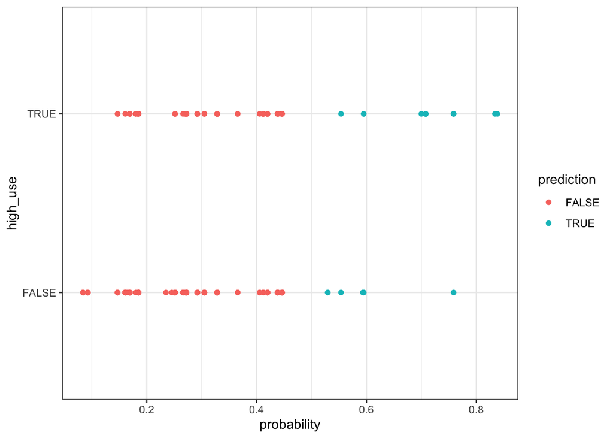

```r
ggplot(factor_student_alc,
       aes(x = probability, y = high_use, col = prediction)) +
  geom_point() +
  theme_bw()
```

```r
loss_func <- function(class, prob) {
  n_wrong <- abs(class - prob) > 0.5
  mean(n_wrong)
}

loss_func(class = factor_student_alc$high_use, prob = factor_student_alc$probability)
```

```
## [1] 0.2810811
```